# Bitacora 2

## Ordenamiento de literatura

## Análisis estadístico

Dado que la mayor'ia de variables son categ'oricas, primero se realizar'a un proceso de depuración de la base con el fin de reducir el n'umero de variables estudiados. Para ello, primeramente se reducirán la cantidad de categorías que existen en cada uno de las variables combinando categorías que compartan carácterísticas o presenten muy pocas observaciones. Por ejemplo, en el caso de la variable del Próposito del Crédito, hay 11 categorías diferentes pero se simplificó de tal manera que solo hubiera 4 categorías. La primera son los préstamos relacionados a la compra de un Automóvil, ya sea nuevo o de segunda mano. La segunda a los préstamos realizados al Hogar, ya sea para compra de muebles o remodelaciones. Una tercera catogoría relacionada a créditos Empresariales y una última categoría que incluyera todos los préstamos cuya razón de solicitud no entre en las categorías anteriores.

```r
library(readr)
library(dplyr)
library(tidyverse)
library(formattable)
library(kableExtra)
library(xtable)
```

```r
library(ggplot2)
library(hrbrthemes)
library(viridis)
data <- read_csv("german.csv")
attach(data)


data <- data %>% mutate(Account_Balance = case_when(Account_Balance == 1 ~ 1,
                           Account_Balance == 2 ~ 2,
                           Account_Balance %in% c(3,4) ~ 3 ))

data <- data %>% mutate(Payment_Status_of_Previous_Credit = case_when(
  Payment_Status_of_Previous_Credit %in% c(0,1) ~ 1,
  Payment_Status_of_Previous_Credit %in% c(2,4) ~ 2,
  Payment_Status_of_Previous_Credit == 3 ~ 3))

data <- data %>%  mutate(Value_Savings_Stocks = case_when(
  Value_Savings_Stocks == 1 ~ 1,
  Value_Savings_Stocks == 2 ~ 2,
  Value_Savings_Stocks %in% c(3,4) ~ 3,
  Value_Savings_Stocks == 5 ~ 4
))


data <- data %>% mutate(Length_of_current_employment = case_when(
  Length_of_current_employment %in% c(1,2) ~ 1,
  Length_of_current_employment == 3 ~ 2,
  Length_of_current_employment == 4 ~ 3,
  Length_of_current_employment == 5 ~ 4
))

data <- data %>% mutate(Sex_Marital_Status = case_when(
  Sex_Marital_Status %in% c(1,2) ~ 1,
  Sex_Marital_Status == 3 ~ 2,
  Sex_Marital_Status == 4 ~ 3
))

data <- data %>%  mutate(No_of_Credits_at_this_Bank = case_when(
  No_of_Credits_at_this_Bank == 1 ~ 1,
  No_of_Credits_at_this_Bank %in% c(2,3,4) ~ 2
))

data <- data %>% mutate(Guarantors = case_when(
  Guarantors == 1 ~ 1,
  Guarantors == 2 ~ 2
))

data <- data %>% mutate(Concurrent_Credits = case_when(
  Concurrent_Credits %in% c(1,2) ~ 1,
  Concurrent_Credits == 3 ~ 2
))

data <- data %>%  mutate(Purpose = case_when(
  Purpose %in% c(1,2) ~ 1,
  Purpose %in% c(3,4,5,6) ~ 2,
  Purpose == 10 ~ 3,
  Purpose %in% c(7,8,9,0) ~ 4
))
```

```r
tabla1 <- data %>% group_by(Purpose) %>% summarize(n =n())

tabla1 %>% kbl(caption="Distribución de la variable Próposito del Crédito",
      format="latex",
      col.names = c("Próposito","Cantidad de observaciones"), align = 'c')%>%
  footnote(general = "Elaboración propia con datos extraídos de Kaggle") %>% kable_styling(latex_options = "HOLD_position")
```

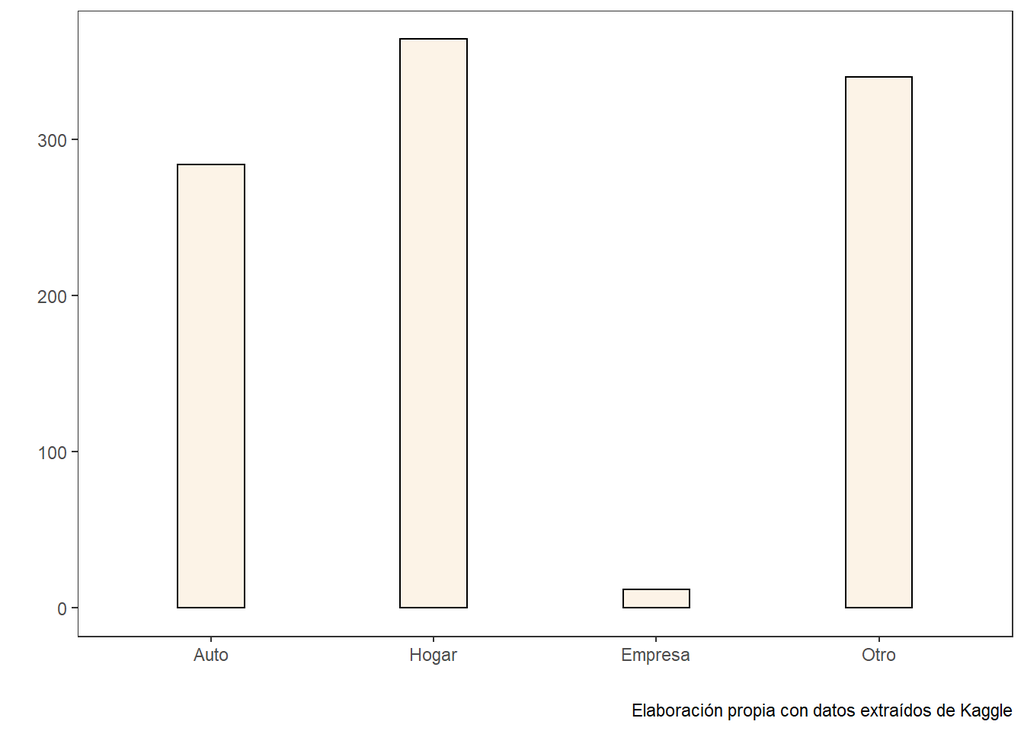

Distribución de la variable Próposito del crédito

```r
graph6 <- tabla1 %>% ggplot(aes(x = Purpose, y = n)) +
  geom_bar(stat="identity", alpha=.6, width=.3, color = "black", fill = "antiquewhite")+
  #coord_flip()+
  theme_test()+
  labs(x = "", y = "", caption = "Elaboración propia con datos extraídos de Kaggle")+
  scale_x_discrete(limits = c("Auto", "Hogar", "Empresa", "Otro"))
graph6
```

Asimismo, en el siguiente gráfico se muestra la relación que existe entre el monto del crédito según su razón, donde cabe destacar que aunque los motivos empresariales es la razón menos frecuente en la base de datos, el crédito solicitado de mayor monto tiene como razón dicho motivo. Mediante este análisis fue que se descartó la posibilidad de combinar la prósito “Empresa” con alguna otra, pues es de esperarse que haya información importante que pueda revelar.

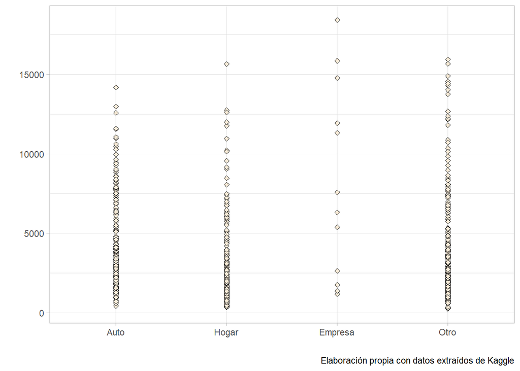

Distribución del Monto del Crédito según su próposito

```r
graph5 <- data %>% ggplot(aes(x=Purpose, y = Credit_Amount)) +
  geom_point(fill = "antiquewhite", color = "black", shape =  23)+
  theme_light()+
  labs(x = "", y = "", caption = "Elaboración propia con datos extraídos de Kaggle")+
  scale_x_discrete(limits = c("Auto", "Hogar", "Empresa", "Otro"))
graph5
```

```r
tabla2 <- data %>%  group_by(Age = cut(Age_years, breaks = c(10,20,30,40,50,60,70,80))) %>% count(Age) %>% na.omit(tabla1)

tabla2 %>% kbl(caption="Distribución de las edades",
      format="latex",
      col.names = c("Rango de edad","Cantidad de observaciones"), align = 'c') %>%
  footnote(general = "Elaboración propia con datos extraídos de Kaggle")%>% kable_styling(latex_options = "HOLD_position")
```

De manera gráfica, la densidad de la variable edad viene dada por el siguiente gráfico donde se nota una asimetría hacia a la derecho que deja en evidencia lo que se habló anteriormente donde hay una tendencia mucho mayor en las personas entre los 20 y los 40 años de solictar préstamos.

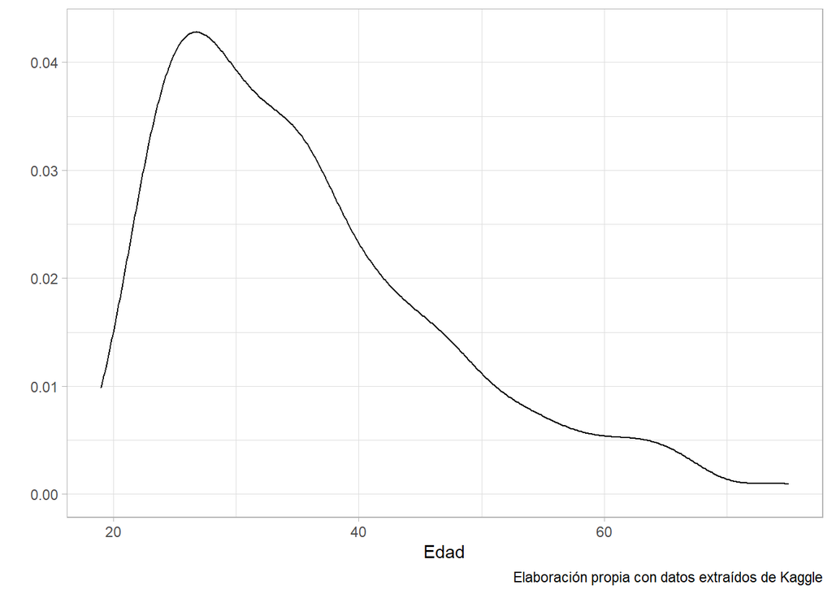

```r
graph3 <- data %>% ggplot(aes(x = Age_years))+
  #geom_histogram(fill = "antiquewhite", color = "black")+
  geom_density()+
  theme_light()+
  labs(x = "Edad", y = "", caption = "Elaboración propia con datos extraídos de Kaggle")
graph3
```

```r
tabla4 <- data %>% group_by(Account_Balance) %>% summarize(n =n())

tabla4 %>% kbl(caption="Distribución de la variable Balance Actual",
      format="latex",
      col.names = c("Balance Actual","Cantidad de observaciones"), align = 'c') %>%
  footnote(general = "Elaboración propia con datos extraídos de Kaggle")%>% kable_styling(latex_options = "HOLD_position")
```

```r
tabla3.1 <- data %>% summarize(
  Min = min(Credit_Amount),
  Q1 = quantile(Credit_Amount, 0.25),
  Mediana = median(Credit_Amount),
  Q3 = quantile(Credit_Amount,0.75),
  Max = max(Credit_Amount)
)

tabla3.2 <- data %>% summarize(
  Min = min(Duration_of_Credit_monthly),
  Q1 = quantile(Duration_of_Credit_monthly, 0.25),
  Mediana = median(Duration_of_Credit_monthly),
  Q3 = quantile(Duration_of_Credit_monthly,0.75),
  Max = max(Duration_of_Credit_monthly)
)


tabla3.3 <- data %>% summarize(
  Min = min(Age_years),
  Q1 = quantile(Age_years, 0.25),
  Mediana = median(Age_years),
  Q3 = quantile(Age_years,0.75),
  Max = max(Age_years)
)

tabla3 <- rbind(tabla3.1, tabla3.2, tabla3.3)
rownames(tabla3) <- c("Monto del crédito", "Duración en meses del crédito", "Edad")
tabla3 %>% kbl(caption="Resumen de 5 números",
      format="latex", align = 'c') %>%
  footnote(general = "Elaboración propia con datos extraídos de Kaggle")%>% kable_styling(latex_options = "HOLD_position")
```

Dado a que eventualmente la idea es realizar un modelo de Cópulas entre los resultados del proceso de clasificación de los solicitantes con la variable Monto del Crédito, sería importante describir de manera exhaustiva esta variable. A continuación un histograma que muestrala distribución de los montos:

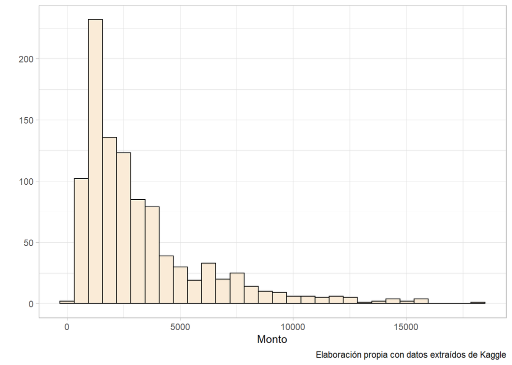

Histograma de la variable Monto del Crédito

```r
graph2 <- data %>% ggplot(aes(x = Credit_Amount))+
  geom_histogram(fill = "antiquewhite", color = "black")+
  theme_light()+
  labs(x = "Monto", y = "", caption = "Elaboración propia con datos extraídos de Kaggle")
graph2
```

El histograma muestra una fuerte asimetría hacia su derecho indicando la tendencia en la solicitud de crédito de montos bajos. Esto en efecto se puede ver el siguiente diagrama de caja y bigotes que también busca mostrar de manera más detallada la distribución intercuantílica de los montos:

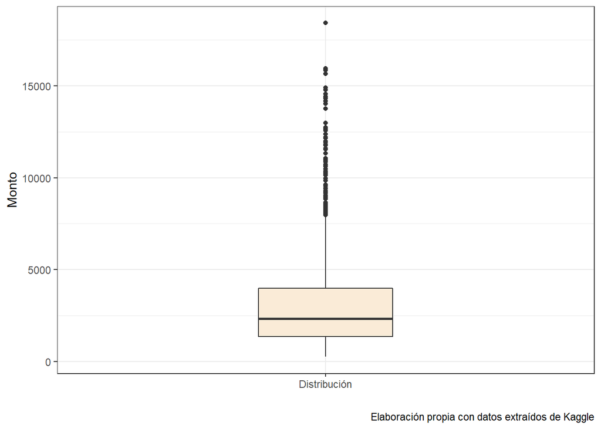

Diagrama de Caja y Bigotes de la variable Monto del Crédito

```r
data.graph1 <- data.frame(
  name = c(rep("Distribución",1000)),
  value = Credit_Amount
)

graph1 <- data.graph1 %>% ggplot(aes(x=name,y=Credit_Amount)) +
  geom_boxplot(width = 0.3, fill = "antiquewhite") +
  scale_fill_viridis(discrete = TRUE, alpha=0.6) +
  # theme_ipsum() +
  theme_bw()+
  theme(
    legend.position="none",
    plot.title = element_text(size=11)
  ) +
  labs(x = "", y = "Monto", caption = "Elaboración propia con datos extraídos de Kaggle")

graph1
```

El gráfico es congruente con lo visto en el histograma y queda aún más en evidencia lo dicho anteriormente pues alrededor del 50$\%$ de los créditos solicitados fueron por montos menores a los 2500 DM que si comparamos este momento con el monto máximo solicitado de 18424 DM, se puede notar una gran diferencia.

```r
tabla5 <- data %>%  group_by(Foreign_Worker) %>%  summarize(n = n())
```